# **EasyVisa_Predicting Visa Approval Outcomes Using Advanced Machine Learning Techniques**

## **Bivariate Analysis**

### **Define functions required for Bivariate Analysis**

```python
# Function to visualize feature distribution with respect to target variable
def distribution_plot_wrt_target(data, predictor, target):

    """
    Plot the distribution of a feature split by the target variable

    Parameters
    data: dataframe
    feature: feature
    target: target variable
    """

    # Creating subplots for histogram and boxplots
    fig, axs = plt.subplots(2, 2, figsize = (12, 10))

    # Getting unique target classes
    target_unique = data[target].unique()

    # Histogram for first target class
    axs[0, 0].set_title(f'Distribution of the {predictor}  for target=' + str(target_unique[0]))
    sns.histplot(
        data = data[data[target] == target_unique[0]],
        x = predictor,
        kde = True,
        ax = axs[0, 0],
        color = 'teal',
        stat = 'density',
    )

    # Histogram for second target class
    axs[0, 1].set_title(f'Distribution of the {predictor} for target=' + str(target_unique[1]))
    sns.histplot(
        data = data[data[target] == target_unique[1]],
        x = predictor,
        kde = True,
        ax = axs[0, 1],
        color = 'orange',
        stat = 'density'
    )

    # Boxplot with outliers
    axs[1, 0].set_title('Boxplot with respect to target')
    sns.boxplot(data = data, x = target, y = predictor, ax = axs[1, 0], palette = 'gist_rainbow')

    # Boxplot without outliers
    axs[1, 1].set_title('Boxplot (Without Outliers) with respect to target')
    sns.boxplot(data = data, x = target, y = predictor, ax = axs[1, 1], showfliers = False, palette = 'gist_rainbow')

    # Adjust layout and display plots
    plt.tight_layout()
    plt.show()
```

```python
# Function to show target distribution across categorical feature levels
def stacked_barplot(data, predictor, target):

    """
    Print the category counts and plot a stacked bar chart

    Parameters
    data: dataframe
    predictor: independent variable
    target: target variable
    """

    # Getting number of unique categories
    count = data[predictor].nunique()

    # Selecting target class for sorting categories
    sorter = data[target].value_counts().index[-1]

    # Creating normalized cross tabulation
    tab1 = pd.crosstab(data[predictor], data[target], normalize = 'index').sort_values(
        by = sorter, ascending = False
    )

    # Displaying category wise target proportions
    print(tab1)
    print('-' * 120)

    # Creating stacked barplot
    tab = pd.crosstab(data[predictor], data[target], normalize = 'index').sort_values(
        by = sorter, ascending = False
    )
    tab.plot(kind = 'bar', stacked = True, figsize = (count + 5, 5))

    # Positioning legend outside the plot
    plt.legend(loc = 'lower left', frameon = False)
    plt.legend(loc = 'upper left', bbox_to_anchor = (1, 1))

    # Displaying the plot
    plt.show()
```

### **Numerical Variables**

#### **'no_of_employees' Distribution and Comaparitive Analysis by 'case_status'**

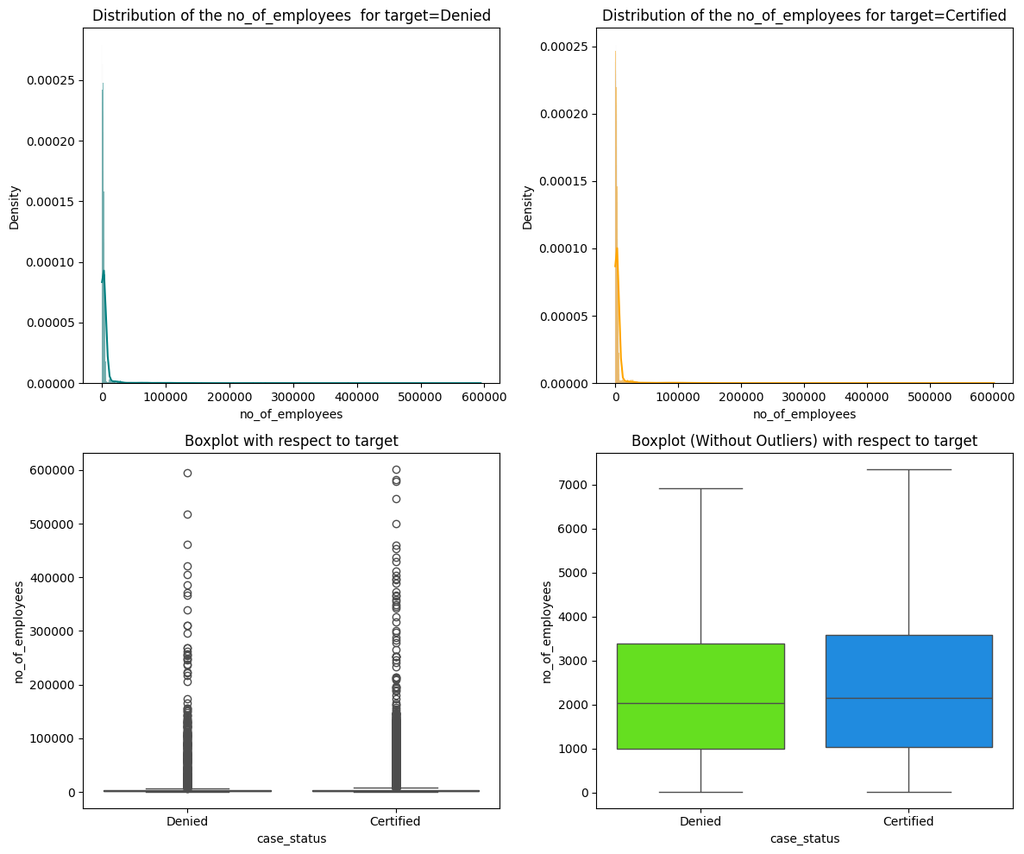

```python
# Visualizing distribution of number of employees across case status
distribution_plot_wrt_target(visa_df, 'no_of_employees', 'case_status')
```

**`Observations:`**

- The distribution of no_of_employees is highly right skewed for both Denied and Certified applications.
- Most employers in both case status groups have a relatively small number of employees, while a few employers have extremely large employee counts.
- The boxplot with outliers shows many high value outliers in both Denied and Certified classes, indicating that very large companies exist in both groups.
- After excluding outliers, the Certified group shows a slightly higher median number of employees compared with the Denied group.
- The overall spread of employee count is also slightly higher for Certified applications, suggesting that larger employers may have a somewhat better certification pattern.
- However, the difference between the two groups is not very large, so no_of_employees alone may not strongly separate Certified and Denied cases.

#### **'yr_of_estab' Distribution and Comaparitive Analysis by 'case_status'**

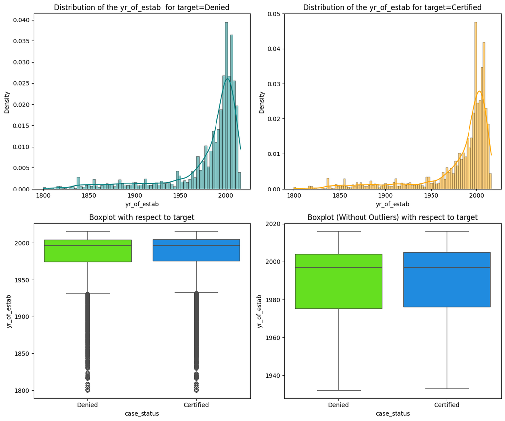

```python
# Visualizing distribution of company establishment year across case status
distribution_plot_wrt_target(visa_df, 'yr_of_estab', 'case_status')
```

**`Observations:`**

- The distribution of yr_of_estab is left skewed for both Denied and Certified applications, with most companies established in recent decades.
- Both case status groups show a high concentration of companies established around the late 1990s and early 2000s.
- The boxplots show several lower end outliers in both groups, representing older companies established much earlier than the majority.
- After excluding outliers, the median establishment year is very similar for Denied and Certified applications.
- The spread of establishment years is also almost the same across both case status groups.
- This suggests that yr_of_estab alone may not be a strong differentiating factor between Certified and Denied applications.

#### **Boxplot of prevailing_wage vs case_status within each unit_of_wage**

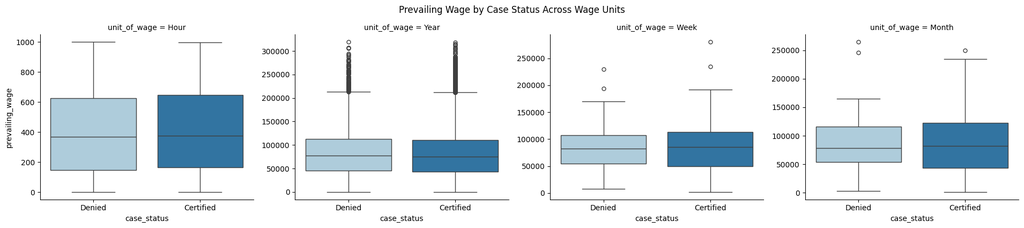

```python
# Comparing prevailing wage by case status within each wage unit
g = sns.catplot(
    data = visa_df,
    x = 'case_status',
    y = 'prevailing_wage',
    col = 'unit_of_wage',
    kind = 'box',
    col_wrap = 4,
    sharey = False,
    height = 4,
    aspect = 1.2,
    palette = 'Paired'
)

# Adding overall title and displaying the plot
g.fig.suptitle('Prevailing Wage by Case Status Across Wage Units', y=1.05)
plt.show()
```

**`Observations:`**

- The relationship between prevailing_wage and case_status varies across different wage units, so comparing wages within each wage unit is more meaningful than comparing all wages together.
- For the Hourly wage unit, the median prevailing wage is almost similar for Denied and Certified applications, with Certified applications showing a slightly higher median.
- For the Yearly wage unit, the median prevailing wage is also very close between Denied and Certified applications, although both groups contain several high value outliers.
- For the Weekly wage unit, Certified applications show a slightly higher median wage and a wider spread compared with Denied applications.
- For the Monthly wage unit, Certified applications have a slightly higher median wage, but the number of monthly wage records appears limited, so this pattern should be interpreted cautiously.
- Overall, prevailing_wage shows some variation across case status within wage units, but the separation between Certified and Denied applications is not very strong based on the boxplots alone.